# Table of Contents

### 3. Data Exploration and Analysis

Analyze from multiple dimensions (region, salary, years of work, education, industry, company size, job requirements), and analyze the regional distribution of data analysts, salary distribution, and the correlation between various fields.

#### 3.1. Demand for data analyst positions in different regions

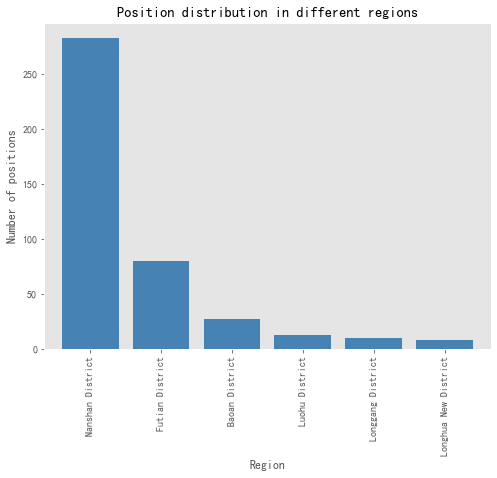

```python
plt.figure(figsize = (8,6))
data['address_english'].value_counts().sort_values(ascending=False).plot.bar(width = 0.8,color = 'steelblue')
plt.ylabel('Number of positions')
plt.xlabel('Region')
plt.title('Position distribution in different regions')
plt.grid(False)
```

#### 3.2. Demand for data analyst positions in different industries

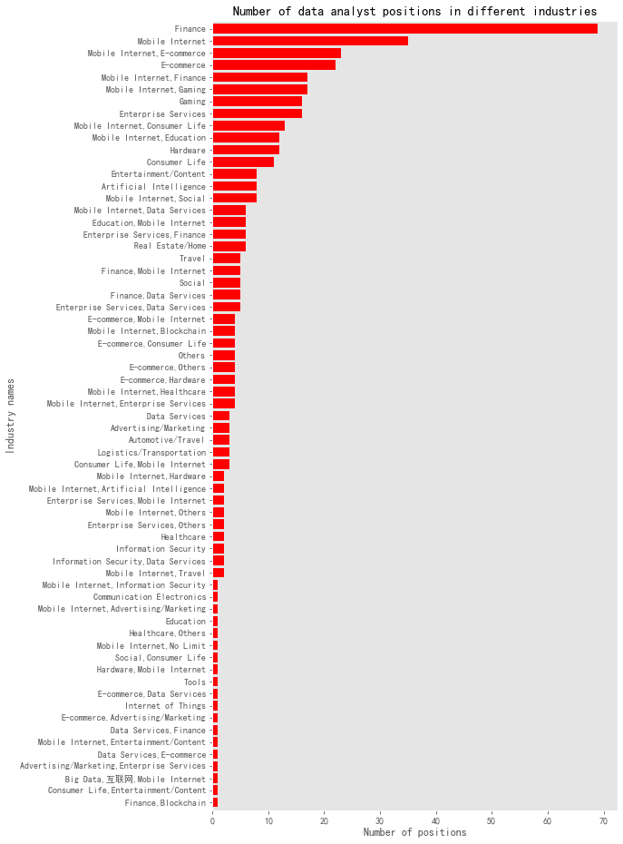

```python
plt.figure(figsize = (8,16))
data['foursquare_english'].value_counts().sort_values(ascending = True).plot.barh(width = 0.8,color = 'red')
plt.xlabel('Number of positions')
plt.ylabel('Industry names')
plt.title('Number of data analyst positions in different industries')
plt.grid(False)
```

Summary: It can be found that data analyst positions are mainly concentrated in the mobile Internet industry. In addition, data analysis positions have also begun to integrate into traditional industries such as finance, e-commerce, enterprise services, consumer life, etc. It can be foreseen that this proportion will continue to increase in the near future, and its development momentum cannot be underestimated.

#### 3.3. Work Experience Requirements for Data Analysts

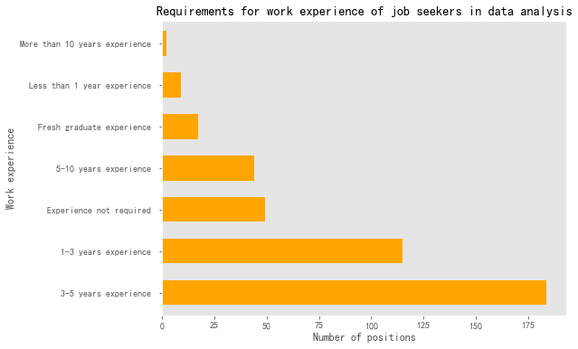

```python
plt.figure(figsize = (8,6))
data['experience_english'].value_counts().plot.barh(width = 0.6,color = 'orange')
plt.xlabel('Number of positions')
plt.ylabel('Work experience')
plt.title('Requirements for work experience of job seekers in data analysis',loc = "center")
plt.grid(False)
```

Summary: Most companies require job seekers to have a certain amount of work experience (everyone wants to hire an employee who can get started directly, rather than spending some time training him), even more than 3 years of work experience, which is actually very disadvantageous for fresh graduates.

#### 3.4. Education Requirements for Data Analysts

```
 [Text(-1.384397649385882, -0.31597966449574627, 'Bachelor degree and above'),
 [Text(-0.7994408961242417, -0.18246713020176897, '73.8%'),
```

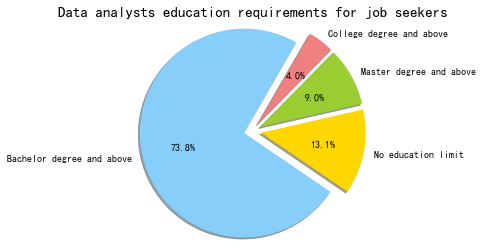

```python
education_count = data['education'].value_counts()
labels='Bachelor degree and above','No education limit','Master degree and above','College degree and above'
colors=[ 'lightskyblue', 'gold','yellowgreen', 'lightcoral']
explode=(0.1,0.1,0.1,0.1)
plt.axis('equal')
plt.title('Data analysts education requirements for job seekers',size = 15)
plt.pie(education_count,explode=explode,labels=labels,colors=colors,autopct='%1.1f%%',
shadow=True,labeldistance=1.1,startangle=60,radius=1.2)
```

Summary: It can be found that the educational requirements for data analyst positions are not too high. Most companies only require a bachelor's degree. This is because data analyst positions only require job seekers to have basic mathematical knowledge and programming, which is not as high as algorithm positions. Therefore, data analyst is still a good job choice for most people.

#### 3.5. Salary range distribution of data analysts

```python
# Remove 'k' or 'K' characters from the salary field
clean_salary = [re.sub('[k|K]', '', i) for i in data.salary]

# Convert the salary data to DataFrame format
salary = pd.DataFrame(clean_salary, columns=['salary'])
salary_s = pd.DataFrame((x.split('-') for x in salary['salary']), columns=['bottomSalary', 'topSalary'])

# Change the field format
salary_s['bottomSalary'] = salary_s['bottomSalary'].astype(np.int)
salary_s['topSalary'] = salary_s['topSalary'].astype(np.int)

# Calculate the average value
salary_avg = [(salary_s['bottomSalary'][i] + salary_s['topSalary'][i]) / 2 for i in range(len(salary_s))]
salary_s['avgSalary'] = salary_avg

# Concatenate the salary_s table with the original table
data = pd.merge(data, salary_s, right_index=True, left_index=True)
data.head()
```

|  | company | foursquare | trend | figure | job | salary | experience | education | description | address | foursquare_english | experience_english | education_english | address_english | salary_min | salary_max | salary_avg | bottomSalary | topSalary | avgSalary |
| --- | --- | --- | --- | --- | --- | --- | --- | --- | --- | --- | --- | --- | --- | --- | --- | --- | --- | --- | --- | --- |
| 0 | YIDATEC | 移动互联网,游戏 | 不需要融资 | 2000人以上 | 数据分析师 | 7k-10k | 经验1-3年 | 本科及以上 | 1、1年以上数据分析\数据运营相关工作经验；2、接触过Android App运营、对App质... | 南山区 | Mobile Internet,Gaming | 1-3 years experience | Bachelor's degree or above | Nanshan District | 7000 | 10000 | 8500.0 | 7 | 10 | 8.5 |
| 1 | 希为科技 | 企业服务,金融 | 不需要融资 | 50-150人 | 数据分析师 | 15k-25k | 经验1-3年 | 本科及以上 | 职位诱惑：14薪；年轻有活力的团队；五险一金；职位描述：岗位职责:1.深入理解业务，通过数据... | 南山区 | Enterprise Services,Finance | 1-3 years experience | Bachelor's degree or above | Nanshan District | 15000 | 25000 | 20000.0 | 15 | 25 | 20.0 |
| 2 | 传易 | 移动互联网,社交 | 不需要融资 | 150-500人 | 数据分析专员(J10236) | 10k-15k | 经验不限 | 学历不限 | 工作职责:1、负责运营数据整理规划工作，监控日常关键数据并分析异常变化，提交数据分析报告；2... | 南山区 | Mobile Internet,Social | Experience not required | No education requirement | Nanshan District | 10000 | 15000 | 12500.0 | 10 | 15 | 12.5 |
| 3 | 盛业资本 | 金融,数据服务 | 上市公司 | 150-500人 | 数据分析师 | 15k-30k | 经验3-5年 | 学历不限 | 岗位职责:1、基于业务需求，规划分析思路，完成从数据提取、数据清洗、数据分析和报告产出的整个... | 福田区 | Finance,Data Services | 3-5 years experience | No education requirement | Futian District | 15000 | 30000 | 22500.0 | 15 | 30 | 22.5 |
| 4 | 路行通 | 移动互联网,消费生活 | 不需要融资 | 500-2000人 | 数据分析师（碰撞场景探索与... | 14k-20k | 经验3-5年 | 本科及以上 | 岗位职责：1.负责车辆碰撞场景的深度探索及数据建模。2.负责车辆碰撞数据的新特征挖掘和衍生，... | 南山区 | Mobile Internet,Consumer Life | 3-5 years experience | Bachelor's degree or above | Nanshan District | 14000 | 20000 | 17000.0 | 14 | 20 | 17.0 |

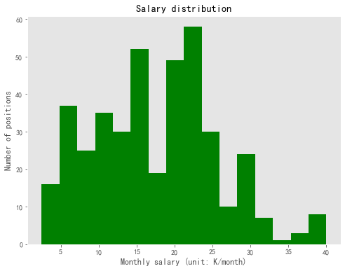

```python
plt.figure(figsize = (8,6))
plt.hist(data['avgSalary'],bins=16,color='green')
plt.axis('tight')
plt.title('Salary distribution')
plt.xlabel('Monthly salary (unit: K/month)')
plt.ylabel('Number of positions')
plt.grid(False)
```

Summary: It can be found that the salary distribution range of data analysts is mainly between 6K-25K, especially concentrated around 20K, and a small number of positions even reach 40K or more. If you work hard, you will have a good future.

#### 3.6. Relationship Between Company Size and Salary

```
{'whiskers': [<matplotlib.lines.Line2D at 0x16385cb6490>,
 'caps': [<matplotlib.lines.Line2D at 0x16385cb6b50>,
 'boxes': [<matplotlib.lines.Line2D at 0x16385cb6130>,
 'medians': [<matplotlib.lines.Line2D at 0x16385cc0250>,
 'fliers': [<matplotlib.lines.Line2D at 0x16385cc05b0>,
 'means': []}
```

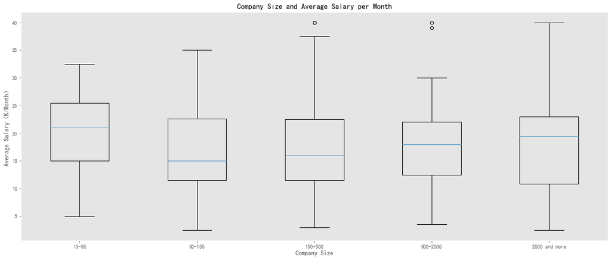

```python
data['figure'] = data['figure'].map(str.strip)
data.groupby(['figure']).count()

size1=data.loc[data['figure'] == '15-50人',['figure','avgSalary']]
size2=data.loc[data['figure'] == '50-150人',['figure','avgSalary']]
size3=data.loc[data['figure'] == '150-500人',['figure','avgSalary']]
size4=data.loc[data['figure'] == '500-2000人',['figure','avgSalary']]
size5=data.loc[data['figure'] == '2000人以上',['figure','avgSalary']]

plt.figure(figsize = (20,8))
plt.xlabel('Company Size')
plt.ylabel('Average Salary（K/Month）')
plt.title('Company Size and Average Salary per Month')
plt.grid(False)
plt.boxplot((size1['avgSalary'],size2['avgSalary'],size3['avgSalary'],size4['avgSalary'],size5['avgSalary']),
            labels=('15-50','50-150','150-500','500-2000','2000 and more'))
# plt.grid(color='#95a5a6',linestyle='--',linewidth=0.8,axis='y',alpha=0.4)
```

#### 3.7. Relationship Between Work Experience and Salary

```python
# Remove spaces from the experience column
data['experience'] = data['experience'].str.strip()

# Classify 'experienced fresh graduates' and 'experience not limited' as 'experience less than 1 year'
data['experience'] = data['experience'].apply(lambda x: '经验1年以下' if x in ['经验应届毕业生', '经验不限'] else x)

# View the results
print(data['experience'].value_counts())
```

```
经验3-5年     183
经验1-3年     107
经验1年以下      68
经验5-10年     44
经验10年以上      2
Name: experience, dtype: int64
```

```
{'whiskers': [<matplotlib.lines.Line2D at 0x16385d7f580>,
 'caps': [<matplotlib.lines.Line2D at 0x16385d7fc40>,
 'boxes': [<matplotlib.lines.Line2D at 0x16385d7f220>,
 'medians': [<matplotlib.lines.Line2D at 0x16385d89340>,
 'fliers': [<matplotlib.lines.Line2D at 0x16385d896a0>,
 'means': []}
```

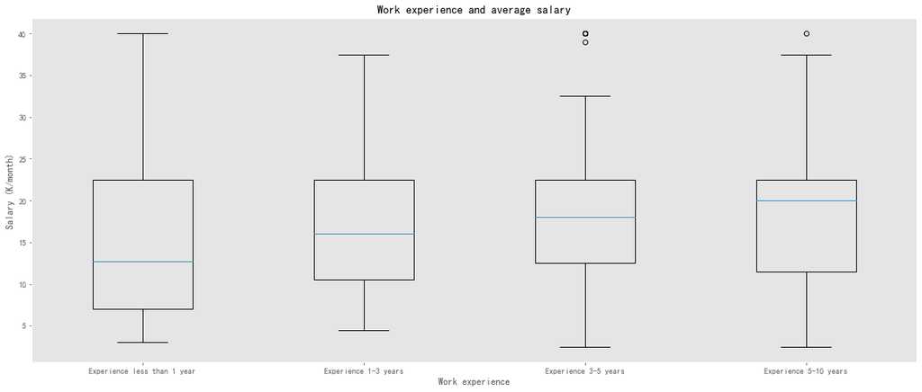

```python
year1=data.loc[data['experience'] == '经验1年以下',['experience','avgSalary']]
year2=data.loc[data['experience'] == '经验1-3年',['experience','avgSalary']]
year3=data.loc[data['experience'] == '经验3-5年',['experience','avgSalary']]
year4=data.loc[data['experience'] == '经验5-10年',['experience','avgSalary']]

plt.figure(figsize = (20,8))
plt.xlabel('Work experience')
plt.ylabel('Salary (K/month)')
plt.title('Work experience and average salary')
plt.grid(False)
# plt.grid(color='#95a5a6',linestyle='--',linewidth=0.8,axis='y',alpha=0.4)
plt.boxplot((year1['avgSalary'],year2['avgSalary'],year3['avgSalary'],year4['avgSalary']),
labels=('Experience less than 1 year','Experience 1-3 years','Experience 3-5 years','Experience 5-10 years'))
```

#### 3.8. Impact of Education on Salary

```
{'whiskers': [<matplotlib.lines.Line2D at 0x16386387ca0>,
 'caps': [<matplotlib.lines.Line2D at 0x163863963a0>,
 'boxes': [<matplotlib.lines.Line2D at 0x16386387940>,
 'medians': [<matplotlib.lines.Line2D at 0x16386396a60>,
 'fliers': [<matplotlib.lines.Line2D at 0x16386396dc0>,
 'means': []}
```

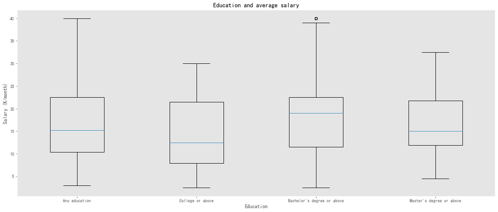

```python
data['education']=data['education'].map(str.strip)

edu1=data.loc[data['education'] == '学历不限',['education','avgSalary']]
edu2=data.loc[data['education'] == '大专及以上',['education','avgSalary']]
edu3=data.loc[data['education'] == '本科及以上',['education','avgSalary']]
edu4=data.loc[data['education'] == '硕士及以上',['education','avgSalary']]

plt.figure(figsize = (20,8))
plt.xlabel('Education')
plt.ylabel('Salary (K/month)')
plt.title('Education and average salary')
plt.grid(False)
# plt.grid(color='#95a5a6',linestyle='--',linewidth=0.8,axis='y',alpha=0.4)
plt.boxplot((edu1['avgSalary'],edu2['avgSalary'],edu3['avgSalary'],edu4['avgSalary']),labels=('Any education','College or above',"Bachelor's degree or above","Master's degree or above"))
```

#### 3.9. Key Skills for Data Analyst Positions

```python
# Connect each job description and save it in a file
description_text = ' '.join([i for i in data['description']])

with open('des.txt','w',encoding = 'utf-8') as f:
    f.write(description_text)
    f.close()
```

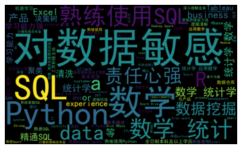

```python
text = open('des.txt', 'r',encoding='utf-8').read()
stop_word = ['岗位职责','任职要求','工作职责','岗位要求','任职资格','本科及以上学历','本科以上学历','职位描述',
             '工作职责','岗位职责1','职位诱惑','职位要求','任职要求1','工作职责1','职位职责','计算机','数据分析',
             'and','to','with','the','in','for','of']
wordcloud = WordCloud(font_path="./SimHei.ttf",
                      stopwords=stop_word,  # 去掉停用词
                      max_words=100,
                      width=2000,
                      height=1200).generate(text)

wordcloud.to_file('DT.jpg')

plt.imshow(wordcloud)
plt.axis("off")
plt.show()
```

Summary: The word cloud shows that if you want to work in the position of data analysis, mathematical statistics, SQL, Python, and Excel are essential skills, as well as data sensitivity and strong sense of responsibility, because data is your magic weapon. From the word cloud, it can be seen that the frequency of data analyst skills is at the forefront: SQL, Python, mathematical statistics, data sensitivity, Excel, SAS, SPSS, Hadoop, machine learning, etc.

### 4. Feature Engineering and Analysis Conclusion

```python
dummies = pd.get_dummies(data[['trend', 'experience', 'education']], drop_first=True)

# Add dummy variables to the original dataset
data_final_with_dummies = pd.concat([data, dummies], axis=1)

# Add dummy variables to the original dataset
data_final_with_dummies = pd.concat([data_final, dummies], axis=1)

# Check the processed dataset
print(data_final_with_dummies.head())
```

```
   company  foursquare  trend     figure               job   salary  \
0  YIDATEC    移动互联网,游戏  不需要融资    2000人以上             数据分析师   7k-10k
1     希为科技     企业服务,金融  不需要融资    50-150人             数据分析师  15k-25k
2       传易    移动互联网,社交  不需要融资   150-500人    数据分析专员(J10236)  10k-15k
3     盛业资本     金融,数据服务   上市公司   150-500人             数据分析师  15k-30k
4      路行通  移动互联网,消费生活  不需要融资  500-2000人  数据分析师（碰撞场景探索与...  14k-20k

  experience education                                        description  \
0    经验1-3年     本科及以上   1、1年以上数据分析\数据运营相关工作经验；2、接触过Android App运营、对App质...
1    经验1-3年     本科及以上   职位诱惑：14薪；年轻有活力的团队；五险一金；职位描述：岗位职责:1.深入理解业务，通过数据...
2      经验不限      学历不限   工作职责:1、负责运营数据整理规划工作，监控日常关键数据并分析异常变化，提交数据分析报告；2...
3    经验3-5年      学历不限   岗位职责:1、基于业务需求，规划分析思路，完成从数据提取、数据清洗、数据分析和报告产出的整个...
4    经验3-5年     本科及以上   岗位职责：1.负责车辆碰撞场景的深度探索及数据建模。2.负责车辆碰撞数据的新特征挖掘和衍生，...

  address  ... trend_不需要融资 trend_天使轮 trend_未融资 experience_经验10年以上  \
```

[output cut: 21 more lines]

```python
import pandas as pd

# Assume your salary column is stored in the form of "7k-10k"
# Split the 'salary' column into 'salary_min' and 'salary_max'
data_final_with_dummies[['salary_min', 'salary_max']] = data_final_with_dummies['salary'].str.extract(r'(\d+)k-(\d+)k')

# Convert 'salary_min' and 'salary_max' to numeric type and multiply by 1000
data_final_with_dummies['salary_min'] = data_final_with_dummies['salary_min'].astype(float) * 1000
data_final_with_dummies['salary_max'] = data_final_with_dummies['salary_max'].astype(float) * 1000

# Calculate the average salary and store it in decimal form
data_final_with_dummies['salary_avg'] = (data_final_with_dummies['salary_min'] + data_final_with_dummies['salary_max']) / 2

# View the converted result
print(data_final_with_dummies[['salary', 'salary_avg']].head())
```

```
    salary  salary_avg
0   7k-10k      8500.0
1  15k-25k     20000.0
2  10k-15k     12500.0
3  15k-30k     22500.0
4  14k-20k     17000.0
```

```python
data_final_with_dummies.info()
```

```
<class 'pandas.core.frame.DataFrame'>
Int64Index: 420 entries, 0 to 435
Data columns (total 31 columns):
 #   Column              Non-Null Count  Dtype
---  ------              --------------  -----
 0   company             420 non-null    object
 1   foursquare          420 non-null    object
 2   trend               420 non-null    object
 3   figure              420 non-null    object
 4   job                 420 non-null    object
 5   salary              420 non-null    object
 6   experience          420 non-null    object
 7   education           420 non-null    object
 8   description         420 non-null    object
 9   address             420 non-null    object
```

[output cut: 23 more lines]

```python
# check the number of missing items
missing_values_per_column = data_final_with_dummies.isnull().sum()
print(missing_values_per_column)
```

```
company                0
foursquare             0
trend                  0
figure                 0
job                    0
salary                 0
experience             0
education              0
description            0
address                0
foursquare_english     0
experience_english     0
education_english      0
address_english        0
salary_min             0
salary_max             0
salary_avg             0
trend_B轮              16
trend_C轮              16
trend_D轮及以上           16
trend_上市公司            16
trend_不需要融资           16
trend_天使轮             16
trend_未融资             16
experience_经验10年以上    16
experience_经验1年以下     16
experience_经验3-5年     16
experience_经验5-10年    16
education_学历不限        16
education_本科及以上       16
education_硕士及以上       16
dtype: int64
```

```python
# check each row of missing proportions
missing_values_percentage = (data_final_with_dummies.isnull().sum() / len(data_final_with_dummies)) * 100
print(missing_values_percentage)
```

```
company               0.000000
foursquare            0.000000
trend                 0.000000
figure                0.000000
job                   0.000000
salary                0.000000
experience            0.000000
education             0.000000
description           0.000000
address               0.000000
foursquare_english    0.000000
experience_english    0.000000
education_english     0.000000
address_english       0.000000
salary_min            0.000000
salary_max            0.000000
salary_avg            0.000000
trend_B轮              3.809524
trend_C轮              3.809524
trend_D轮及以上           3.809524
trend_上市公司            3.809524
trend_不需要融资           3.809524
trend_天使轮             3.809524
trend_未融资             3.809524
experience_经验10年以上    3.809524
experience_经验1年以下     3.809524
experience_经验3-5年     3.809524
experience_经验5-10年    3.809524
education_学历不限        3.809524
education_本科及以上       3.809524
education_硕士及以上       3.809524
dtype: float64
```

```python
# check missing value
rows_with_missing_values = data_final_with_dummies[data_final_with_dummies.isnull().any(axis=1)]
print(rows_with_missing_values)
```

```
      company  foursquare  trend  \
420      德因科技          电商  不需要融资
421  花旦传媒有限公司       移动互联网  不需要融资
422      寻找母星  移动互联网,消费生活     A轮
423      智策科技      金融,区块链    天使轮
424       4PX    移动互联网,电商  D轮及以上
425       蒙智拓          电商  不需要融资
426      鲁班到家        消费生活    天使轮
427        宜搜    移动互联网,游戏  D轮及以上
428    丹尼尔惠灵顿        消费生活  不需要融资
429      美团点评        消费生活   上市公司
430   CMGE中手游    移动互联网,游戏   上市公司
431        友朋        消费生活     A轮
432      艾宝电子          电商  不需要融资
433      点购商城          金融  D轮及以上
```

[output cut: 112 more lines]

填充缺失值

```python
data_final_with_dummies.fillna(0, inplace=True)

print(data_final_with_dummies.isnull().sum())
```

```
company               0
foursquare            0
trend                 0
figure                0
job                   0
salary                0
experience            0
education             0
description           0
address               0
foursquare_english    0
experience_english    0
education_english     0
address_english       0
salary_min            0
salary_max            0
salary_avg            0
trend_B轮              0
trend_C轮              0
trend_D轮及以上           0
trend_上市公司            0
trend_不需要融资           0
trend_天使轮             0
trend_未融资             0
experience_经验10年以上    0
experience_经验1年以下     0
experience_经验3-5年     0
experience_经验5-10年    0
education_学历不限        0
education_本科及以上       0
education_硕士及以上       0
dtype: int64
```

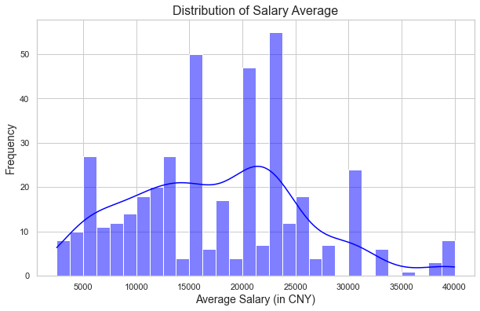

```python
sns.set(style="whitegrid")
plt.figure(figsize=(10, 6))
sns.histplot(data_final_with_dummies['salary_avg'], kde=True, bins=30, color='blue')
plt.title('Distribution of Salary Average', fontsize=16)
plt.xlabel('Average Salary (in CNY)', fontsize=14)
plt.ylabel('Frequency', fontsize=14)
plt.show()
```

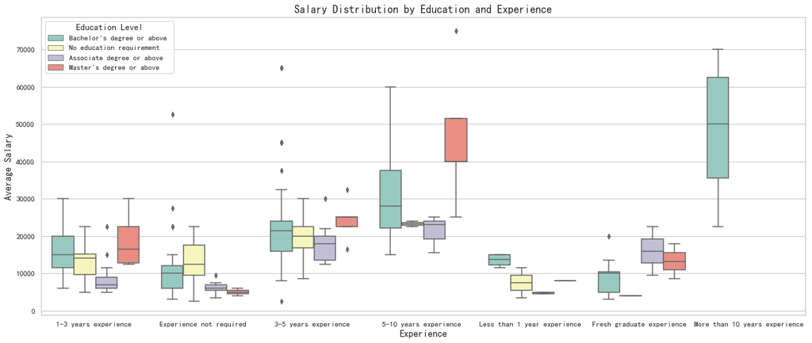

```python
plt.rcParams['font.sans-serif'] = ['SimHei']
plt.rcParams['axes.unicode_minus'] = False

plt.figure(figsize=(20, 8))
sns.boxplot(x='experience_english', y='salary_avg', hue='education_english', data=data_filtered, palette="Set3")

plt.title('Salary Distribution by Education and Experience', fontsize=16)
plt.xlabel('Experience', fontsize=14)
plt.ylabel('Average Salary', fontsize=14)
plt.legend(title='Education Level', title_fontsize='13', fontsize='11')

plt.show()
```

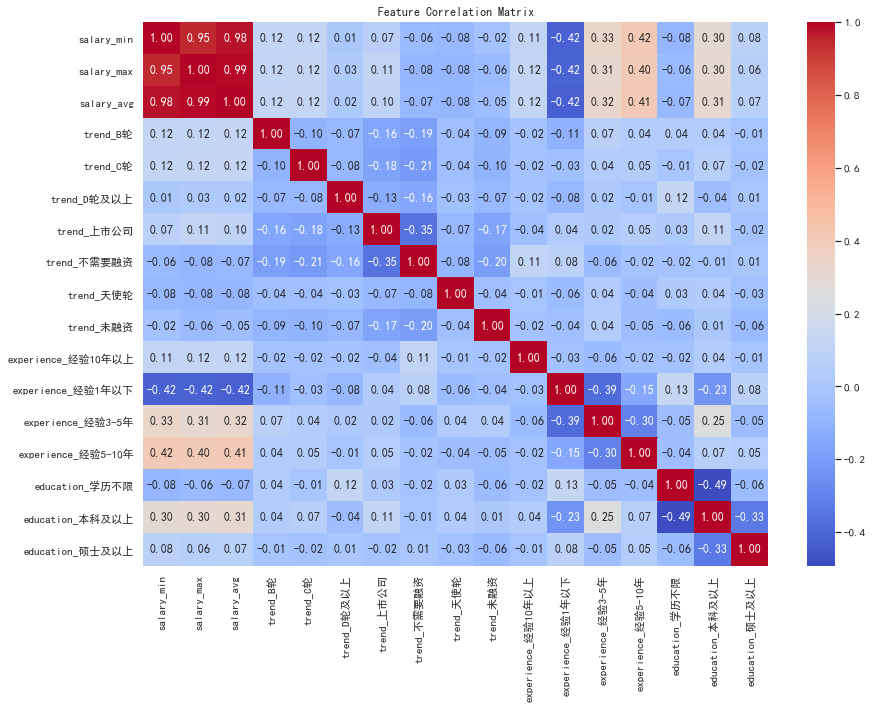

```python
plt.rcParams['font.sans-serif'] = ['SimHei']
plt.rcParams['axes.unicode_minus'] = False
correlation_matrix = data_final_with_dummies.corr()

plt.figure(figsize=(14, 10))
sns.heatmap(correlation_matrix, annot=True, fmt=".2f", cmap='coolwarm')
plt.title('Feature Correlation Matrix')
plt.show()
```

Through the above analysis, we can draw the following conclusions:

b. The industry field distributed by data analysts is mainly the mobile Internet industry, but it has also begun to penetrate into traditional industries (such as finance and education).

c. The most frequently possessed skills of data analysts are: SQL, Python, mathematical statistics, data sensitivity, Excel, SAS, SPSS, Hadoop, machine learning, etc., among which mathematical statistics, SQL, Python, and Excel are essential skills.